# Are Chess Openings and Player Elo Important?

#### By: Lewis Morgan

[figure not shown]

### Introduction:

One of the oldest games in the world, yet many have not pursued the game to greater lengths. Chess is a two-player game played on a checkered, 8x8 board. Both players have the same pieces, but there are rules for how certain pieces can move. The main goal is to 'checkmate' the opponents king which means you attack the enemy's king in a way where the king has nowhere else to go. There are other win conditions such as the opponent running out of time in a timed game, one side forfeiting, or a draw. In online chess, draws can be made by both players agreeing to one or the computer deems that neither side has sufficient material to win. If you are relatively new to the game of chess, you can [learn more here](https://www.chess.com/learn-how-to-play-chess).

A few other factors to point out are starting color, opening moves, and elo which may correlate to wins of a chess game. It is generally considered that whoever starts out with white has a small advantage as they can move first. The idea of this is that black has to usually react to white's moves making it difficult to counter and take the advantage. Opening moves relate to the theory behind chess as a whole. Openings are classified by common initial moves played by both sides. Certain openings may be countered quickly if the opponent knows what they are doing but can also be detrimental, creating traps for the opponent to fall into. Another important factor might be elo. Elo is the computer ranking of players determined by total points. Players with higher elo are generally better and thus are more likely to win games against lower rated players. Small margins between elos however may prove that both players are equally matched. Does the greater elo tend to win more? Does white win more? What are the results of games where black has a higher elo than white? What openings are best for white? What openings are best for black? What openings do players with higher elo tend to use the most? Can we infer what opening one will use depending on their elo? There are a lot of questions already starting to form and we have yet to even start our Data Science Pipeline.

Our main goal is to see if there is any correlation between chess openings and winning the game as well as if their is a correlation between elo and winning a game. Of course, openings and elo are not the only factor in play here so we will be examining more than just these.

### Data Science Pipeline:

The pipeline for data science contains data collection, data management/representation, exploratory data analysis, hypothesis testing and machine learning, as well as the communication of insights gained from analysis. Much like the scientific method, this is not concrete and one should go back to a previous step if it is deemed necessary. For example, if you were to do exploratory data analyis to find out that the data gathered is insufficient, you probably need to collect more relevant data. If you want to learn more about the Data Science Pipeline, [this link](https://medium.com/@thakurinbox/beginners-guide-to-data-science-pipeline-ecb5bedd970b) helps explain the basics! On that note, lets begin our pipeline!

### Data Collection:

First, we need to import packages and libraries that we will be using throughout the tutorial. Links are provided for the general API documentation for each. Feel free to check each of them out!

- [pandas API](https://pandas.pydata.org/pandas-docs/stable/reference/index.html) - helps manage data
- [seaborn API](https://seaborn.pydata.org/api.html) - helps visualize data
- [matplotlib API](https://matplotlib.org/stable/api/index.html) - helps visualize and interpret data
- [numpy API](https://numpy.org/doc/stable/reference/) - helps manage data
- [scikit-learn API](https://scikit-learn.org/stable/modules/classes.html#) - helps visualize and interpret data
- [statsmodels API](https://www.statsmodels.org/stable/api.html) - helps interpret data

```python
import warnings
import pandas as pd
import seaborn as sns
import matplotlib.pyplot as plt
import numpy as np
import sklearn
import statsmodels.api as sm

from sklearn import linear_model
from sklearn.linear_model import LogisticRegression
from pandas.core.common import SettingWithCopyWarning

warnings.simplefilter(action="ignore", category=SettingWithCopyWarning)
```

We will be retrieving the data from a database presented from kaggle. This database contains over 20,000 chess games from lichess (an online chess company). This was achieved by pooling chess 'groups' from lichess which can contain thousands of players. You can find the [dataset here](https://www.kaggle.com/datasnaek/chess?select=games.csv). This dataset had to be downloaded and added to the notebook in order for it to be used.

```python
file = 'games.csv'
games = pd.read_csv(file)
games.head()
```

|  | id | rated | created_at | last_move_at | turns | victory_status | winner | increment_code | white_id | white_rating | black_id | black_rating | moves | opening_eco | opening_name | opening_ply |
| --- | --- | --- | --- | --- | --- | --- | --- | --- | --- | --- | --- | --- | --- | --- | --- | --- |
| 0 | TZJHLljE | False | 1.504210e+12 | 1.504210e+12 | 13 | outoftime | white | 15+2 | bourgris | 1500 | a-00 | 1191 | d4 d5 c4 c6 cxd5 e6 dxe6 fxe6 Nf3 Bb4+ Nc3 Ba5... | D10 | Slav Defense: Exchange Variation | 5 |
| 1 | l1NXvwaE | True | 1.504130e+12 | 1.504130e+12 | 16 | resign | black | 5+10 | a-00 | 1322 | skinnerua | 1261 | d4 Nc6 e4 e5 f4 f6 dxe5 fxe5 fxe5 Nxe5 Qd4 Nc6... | B00 | Nimzowitsch Defense: Kennedy Variation | 4 |
| 2 | mIICvQHh | True | 1.504130e+12 | 1.504130e+12 | 61 | mate | white | 5+10 | ischia | 1496 | a-00 | 1500 | e4 e5 d3 d6 Be3 c6 Be2 b5 Nd2 a5 a4 c5 axb5 Nc... | C20 | King's Pawn Game: Leonardis Variation | 3 |
| 3 | kWKvrqYL | True | 1.504110e+12 | 1.504110e+12 | 61 | mate | white | 20+0 | daniamurashov | 1439 | adivanov2009 | 1454 | d4 d5 Nf3 Bf5 Nc3 Nf6 Bf4 Ng4 e3 Nc6 Be2 Qd7 O... | D02 | Queen's Pawn Game: Zukertort Variation | 3 |
| 4 | 9tXo1AUZ | True | 1.504030e+12 | 1.504030e+12 | 95 | mate | white | 30+3 | nik221107 | 1523 | adivanov2009 | 1469 | e4 e5 Nf3 d6 d4 Nc6 d5 Nb4 a3 Na6 Nc3 Be7 b4 N... | C41 | Philidor Defense | 5 |

We read the csv file from the saved location that was uploaded to the notebook as `games.csv`. The function [read_csv](https://pandas.pydata.org/docs/reference/api/pandas.read_csv.html) is provided by pandas which does all the hard work for us. Now we have a dataframe, similar to a table, called `games` of which each row is a game entry.

### The Data:

Now that we have the data stored in the pandaframe, we can alter it to best suit our needs. We do not need the `id`, `white_id`, or `black_id` as who played the game or how the game is stored in the database is unimportant to us. In addition, we do not need the `created_at` or `last_move_at` column as we are not concerned with the times of the games. Lastly, we will remove the `turn` and the `moves` column which shows the number of moves and every move of the entire game played respectively. We will not be analyzing this either.

```python
columns_to_drop = ['id', 'turns', 'increment_code', 'created_at', 'last_move_at', 'white_id', 'black_id', 'moves', 'opening_ply']
games = games.drop(columns =columns_to_drop)
games.head()
```

|  | rated | victory_status | winner | white_rating | black_rating | opening_eco | opening_name |
| --- | --- | --- | --- | --- | --- | --- | --- |
| 0 | False | outoftime | white | 1500 | 1191 | D10 | Slav Defense: Exchange Variation |
| 1 | True | resign | black | 1322 | 1261 | B00 | Nimzowitsch Defense: Kennedy Variation |
| 2 | True | mate | white | 1496 | 1500 | C20 | King's Pawn Game: Leonardis Variation |
| 3 | True | mate | white | 1439 | 1454 | D02 | Queen's Pawn Game: Zukertort Variation |
| 4 | True | mate | white | 1523 | 1469 | C41 | Philidor Defense |

Now if we look at the columns, we have a lot of data for each game:

- **rated** (true if the game is rated, false if unrated) Note: Rated games directly affect elo
- **victory_status** (outoftime, resign, mate, or draw)
- **winner** (denotes which color won or if there was a draw)
- **white_rating** (white elo)
- **black_rating** (black elo)
- **opening_eco** (standardized code for the opening [listed here](https://www.365chess.com/eco.php))
- **opening_name** (name of the opening)

### Missing Data:

Our data is almost done to move on to the next step of our data science pipeline but first we have to account for missing data in our pandas dataframe. But what is missing data? Missing data is when we don't have data stored for that entry of row, column. In this case, because we used pandas `read_csv`, it filled in empty spaces with NaN already for us. The issue however is that pandas will simply ignore this and treat it as a 0, which is not beneficial and can be misleading. If you want to learn more about missing data and how pandas treats it, you can read more from [their guide](https://pandas.pydata.org/pandas-docs/stable/user_guide/missing_data.html).

```python
# columns to check for missing values
check_nan = ['rated', 'victory_status', 'winner', 'white_rating', 'black_rating', 'opening_eco']

# drop rows that have nan in specified columns
games.dropna(subset=check_nan, inplace=True)
games.head()
```

|  | rated | victory_status | winner | white_rating | black_rating | opening_eco | opening_name |
| --- | --- | --- | --- | --- | --- | --- | --- |
| 0 | False | outoftime | white | 1500 | 1191 | D10 | Slav Defense: Exchange Variation |
| 1 | True | resign | black | 1322 | 1261 | B00 | Nimzowitsch Defense: Kennedy Variation |
| 2 | True | mate | white | 1496 | 1500 | C20 | King's Pawn Game: Leonardis Variation |
| 3 | True | mate | white | 1439 | 1454 | D02 | Queen's Pawn Game: Zukertort Variation |
| 4 | True | mate | white | 1523 | 1469 | C41 | Philidor Defense |

### Exploratory Analysis:

Now that our data is ready to be analyzed we can alter it as we deem necessary to find correlation to who wins. The most obvious data to look at, is elo. If the elo of both players is relatively the same, does white win more on average due to having the first move? Before focusing our attention on openings, and elo, there is a more obvious question, does white win more or does black win more? The classic suggestion that white has a first move advantage seems accurate and plausable. Let's do a simple calculation from our dataset to determine if that is true.

```python
# create a new dataframe that stores ranked games (limits unbalanced elo matchup)
ranked_games = games[games['rated'] == True]

# store wins for both white and black
white_wins = 0
black_wins = 0
total = len(ranked_games)

# iterate through the data frame
for rows in ranked_games.itertuples():
    if rows.winner == 'white':
        white_wins += 1
    if rows.winner == 'black':
        black_wins += 1

# calculate and print win percentage
print('White wins ' + "{:.2f}".format((white_wins/total)*100) + '% of the time')
print('Black wins ' + "{:.2f}".format((black_wins/total)*100) + '% of the time')
print('Players tie ' + "{:.2f}".format(((total - white_wins - black_wins)/total)*100) + '% of the time')
print('White wins ' + "{:.2f}".format(((white_wins/total)*100) - ((black_wins/total)*100)) + '% more of the time than Black')
```

```
White wins 49.84% of the time
Black wins 45.71% of the time
Players tie 4.45% of the time
White wins 4.13% more of the time than Black
```

We create a new dataframe with only the ranked games included to prevent casual games possibly between friends to skew data. At first glance, it seems white generally wins slightly more often than black, but not by much. Is this simply because they have the first move? Possibly, but there are many other factors present such as elo difference and openings played. Let's look at elo next.

```python
# create new column to store the elo difference rating between both players
elo_dif = ranked_games['white_rating'] - ranked_games['black_rating']

#inserts at the column storing elo_dif
ranked_games['elo_dif'] = elo_dif
ranked_games.head()
```

|  | rated | victory_status | winner | white_rating | black_rating | opening_eco | opening_name | elo_dif |
| --- | --- | --- | --- | --- | --- | --- | --- | --- |
| 1 | True | resign | black | 1322 | 1261 | B00 | Nimzowitsch Defense: Kennedy Variation | 61 |
| 2 | True | mate | white | 1496 | 1500 | C20 | King's Pawn Game: Leonardis Variation | -4 |
| 3 | True | mate | white | 1439 | 1454 | D02 | Queen's Pawn Game: Zukertort Variation | -15 |
| 4 | True | mate | white | 1523 | 1469 | C41 | Philidor Defense | 54 |
| 6 | True | resign | white | 1520 | 1423 | D00 | Blackmar-Diemer Gambit: Pietrowsky Defense | 97 |

Now that we have factored out the unrated games and inserted the difference of elo, we can start to visualize our data. We can begin by plotting the wins of both black and white as well as draws based off of elo.

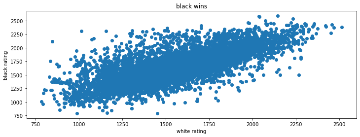

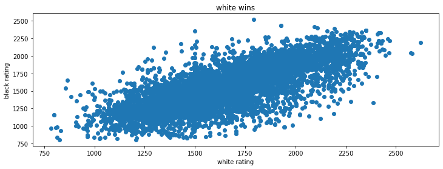

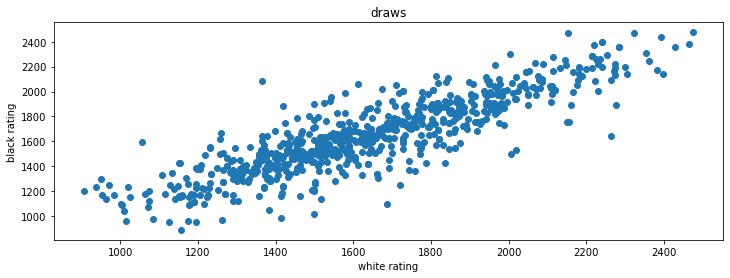

```python
# create scatter plot for each games with black winning, white winning and a draw
# stores each unique value in column 'winner'
won = ranked_games['winner'].unique()

# for black wins, white wins and ties
for win in won:

    # dataframe where
    current_df = ranked_games.loc[ranked_games['winner'] == win]

    # create figure and set dimensions
    fig, ax = plt.subplots()
    fig.set_figwidth(12)

    # plot points
    plt.scatter(current_df['white_rating'], current_df['black_rating'])
    if str(win) == 'draw':
        plt.title(str(win) + 's')
    else:
        plt.title(str(win) + ' wins')
    plt.xlabel('white rating')
    plt.ylabel('black rating')
    plt.show()
```

Here, we use [matplotlib](https://matplotlib.org/stable/tutorials/introductory/pyplot.html) to create three scatter plots for the different outcomes of the games. Upon looking at this, it doesn't tell us much. Even if a linear regression line is plotted for each, what would that tell us? All of the plots have generally the same slope with no way to differientiate the winner. In addition, there is a variation in win percentage when played with white vs. black. In order to combat this we will only look in the perspective of starting with white. Let's begin by looking at elo difference and its distribution.

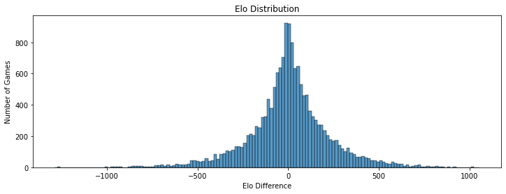

```python
# create plot and set dimensions
fig, ax = plt.subplots()
fig.set_figwidth(12)

# create histogram
sns.histplot(data=ranked_games, x='elo_dif', ax=ax)

# change labels
plt.xlabel('Elo Difference')
plt.ylabel('Number of Games')
plt.title('Elo Distribution')
plt.show()
```

Wow! The elo difference is almost perfectly distributed throughout. A negative number means that black has a higher elo than white while a positive number means that white has an elo advantage instead. Now we can plot wins against the elo difference.

```python
# create new dataframe to store win percentage and elo_difference
df = pd.DataFrame(columns=['elo_dif', 'win_percent'])

# go through each elo difference
for elos in ranked_games['elo_dif'].unique():

    # dataframe where all entries have the same elo_dif
    curr_df = ranked_games.loc[ranked_games['elo_dif'] == elos]

    #calculate win percentage for the current dataframe
    wins = curr_df.loc[curr_df['winner'] == 'white']
    win_percent = len(wins)/len(curr_df)

    # add entry to dataframe
    df = df.append({'elo_dif': elos, 'win_percent': win_percent}, ignore_index = True)

df.head()
```

|  | elo_dif | win_percent |
| --- | --- | --- |
| 0 | 61.0 | 0.538462 |
| 1 | -4.0 | 0.440000 |
| 2 | -15.0 | 0.385714 |
| 3 | 54.0 | 0.651163 |
| 4 | 97.0 | 0.757576 |

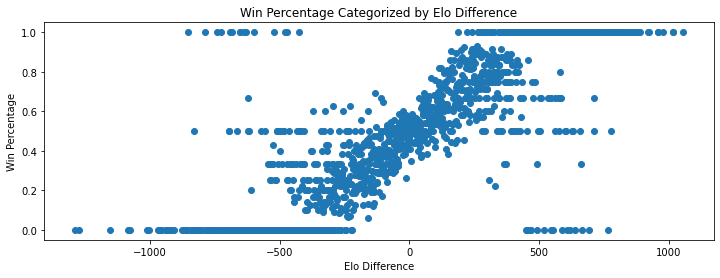

```python
# create plot and set dimensions
fig, ax = plt.subplots()
fig.set_figwidth(12)

# create scatter plot
plt.scatter(df['elo_dif'], df['win_percent'])

# change labels
plt.xlabel('Elo Difference')
plt.ylabel('Win Percentage')
plt.title('Win Percentage Categorized by Elo Difference')
plt.show()
```

We can generally see an upward trend in wins as the elo difference begins to pass -500 and tops off around +500. But what does this mean? When the elo difference is negative, this means that black's rating was higher than white's. When the elo difference is positive, white's rating was higher than blacks.This seems to be a logistic trend rather than linear. Let's plot this using [sklearn](https://scikit-learn.org/stable/supervised_learning.html#supervised-learning). More specifically, we will create a logistic regression because the values only go from 0 to 1 using [seaborn's function](https://seaborn.pydata.org/generated/seaborn.regplot.html#seaborn.regplot). We will also create another logistic regression line using the [statsmodel](https://www.statsmodels.org/stable/api.html) provided by Python. This will help us determine what exactly our equation is showing.

```
Optimization terminated successfully.
         Current function value: 0.427473
         Iterations 6
```

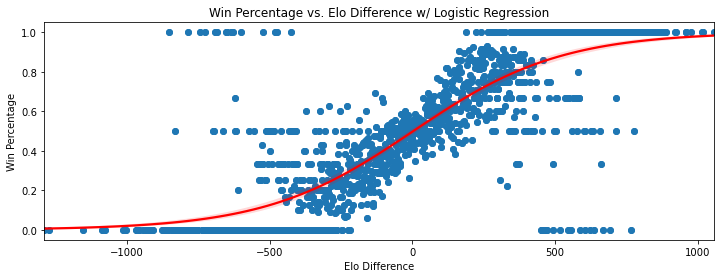

```python
# create plot and set dimensions
fig, ax = plt.subplots()
fig.set_figwidth(12)

# create scatter plot
plt.scatter(df['elo_dif'], df['win_percent'])

# create logistic regression plot from seaborn
ax = sns.regplot(x='elo_dif', y='win_percent', data=df, logistic=True, line_kws={"color": "red"})

# create logistic regression from statsmodel
x = df[['elo_dif']]
y = df[['win_percent']]
logReg = sm.Logit(y, x).fit()

# change labels
plt.xlabel('Elo Difference')
plt.ylabel('Win Percentage')
plt.title('Win Percentage vs. Elo Difference w/ Logistic Regression')
plt.show()
```

### Hypothesis Testing:

The main goal is to come up with an hypothesis regarding elo versus win percentage. Our null hypotheses is one that shows no correlation. In this case, our null hypothesis is elo difference does not matter how much you win. Our alternate hypothesis is that there is a correlation between elo difference and winning. The significance level refers to the probabality of rejecting the null hypothesis if it is true. This value should be around .05 or less which indicates that there is a 5% or less error in saying that there is a relationship when there is not.

```python
print(logReg.summary())
```

```
                           Logit Regression Results
==============================================================================
Dep. Variable:            win_percent   No. Observations:                 1400
Model:                          Logit   Df Residuals:                     1399
Method:                           MLE   Df Model:                            0
Date:                Wed, 21 Jul 2021   Pseudo R-squ.:                  0.3830
Time:                        00:59:21   Log-Likelihood:                -598.46
converged:                       True   LL-Null:                       -970.01
Covariance Type:            nonrobust   LLR p-value:                       nan
==============================================================================
                 coef    std err          z      P>|z|      [0.025      0.975]
------------------------------------------------------------------------------
elo_dif        0.0039      0.000     18.923      0.000       0.003       0.004
==============================================================================
```

We called the summary function which gives us a breakdown of our logistic regression created with the statsmodel package. Here we can easily see that our p value is 0. This means we can reject the null hypothesis that there is no correlation between elo difference and win percentage. We can accept the alternate hypothesis that there is a correlation between these two variables with minimum error.

### Back to The Data!

Now that we have discovered a correlation between elo differences, we can start to look at different openings used and if there exists a correlation. Because we have already found a logistic correlation for elo difference, we want to limit this as much as possible to prevent any misleading evidence. We will start by only looking at games that have a +-100 elo difference. This way, games are more evenly matched and the elo difference should not directly affect the results as much.

```python
# filter out games where elo difference differs by +-100
even_games = ranked_games.loc[(ranked_games['elo_dif'] >= -100) & (ranked_games['elo_dif'] <= 100)]
even_games.head()
```

|  | rated | victory_status | winner | white_rating | black_rating | opening_eco | opening_name | elo_dif |
| --- | --- | --- | --- | --- | --- | --- | --- | --- |
| 1 | True | resign | black | 1322 | 1261 | B00 | Nimzowitsch Defense: Kennedy Variation | 61 |
| 2 | True | mate | white | 1496 | 1500 | C20 | King's Pawn Game: Leonardis Variation | -4 |
| 3 | True | mate | white | 1439 | 1454 | D02 | Queen's Pawn Game: Zukertort Variation | -15 |
| 4 | True | mate | white | 1523 | 1469 | C41 | Philidor Defense | 54 |
| 6 | True | resign | white | 1520 | 1423 | D00 | Blackmar-Diemer Gambit: Pietrowsky Defense | 97 |

### Chess Openings:

There are 365 different chess openings in this data set. Analyzing all of these may cause more harm than help. We are only going to examine the top ten most frequently used ones as it will be difficult to showcase all of them. In addition, this will prevent us from analyzing openings with very few entries or games played with them.

```python
# create dictionary to store number of times the opening is played
open_dict = {}

# for each opening
for opening in even_games['opening_eco'].unique():

    # current dataframe for specific opening
    curr_df = even_games[even_games['opening_eco'] == opening]

    # add entry
    open_dict[opening] = len(curr_df)

# sort items from highest instance to lowest
sort_openings = sorted(open_dict.items(), key=lambda x: x[1], reverse=True)

# grab the top ten most used openings
first_ten = list(sort_openings)[:10]

# pretty print the top ten
for index, tuple in enumerate(first_ten):
    print('Opening Code: ' + tuple[0] + ' Num Times Played: ' + str(tuple[1]))
```

```
Opening Code: C00 Num Times Played: 344
Opening Code: A00 Num Times Played: 314
Opening Code: D00 Num Times Played: 307
Opening Code: C41 Num Times Played: 288
Opening Code: C20 Num Times Played: 273
Opening Code: B01 Num Times Played: 271
Opening Code: A40 Num Times Played: 234
Opening Code: B20 Num Times Played: 229
Opening Code: C50 Num Times Played: 216
Opening Code: B00 Num Times Played: 214
```

```python
# create dataframe for openings
openings = pd.DataFrame(columns=['opening_code', 'times_played'])

# for each of the top ten used openings
for index, tuple in enumerate(first_ten):

    # add entry to dataframe
    openings = openings.append({'opening_code': tuple[0], 'times_played': tuple[1]}, ignore_index = True)

openings
```

|  | opening_code | times_played |
| --- | --- | --- |
| 0 | C00 | 344 |
| 1 | A00 | 314 |
| 2 | D00 | 307 |
| 3 | C41 | 288 |
| 4 | C20 | 273 |
| 5 | B01 | 271 |
| 6 | A40 | 234 |
| 7 | B20 | 229 |
| 8 | C50 | 216 |
| 9 | B00 | 214 |

We created a new dataframe to store the count of games played for the top ten openings. We can now calculate the win percentage for both white and black in each opening of these 10 openings.

```python
# create new columns
white_wins = []
black_wins = []
w_win_perc = []
b_win_perc = []

# for each of the ten openings
for code in openings['opening_code']:

    # current dataframe for specific opening
    curr_df = even_games[even_games['opening_eco'] == code]

    # get white wins
    w_wins = curr_df[curr_df['winner'] == 'white']

    #get black wins
    b_wins = curr_df[curr_df['winner'] == 'black']

    # append to appropriate lists
    white_wins.append(len(w_wins))
    black_wins.append(len(b_wins))

# create new columns and adding to opening data frame
openings['w_wins'] = white_wins
openings['b_wins'] = black_wins

# calculates win percentage and adds to dataframe
for rows in openings.itertuples():
    w_win_perc.append((rows.w_wins)/(rows.times_played))
    b_win_perc.append((rows.b_wins)/(rows.times_played))

# assign column
openings['w_win_perc'] = w_win_perc
openings['b_win_perc'] = b_win_perc

openings
```

|  | opening_code | times_played | w_wins | b_wins | w_win_perc | b_win_perc |
| --- | --- | --- | --- | --- | --- | --- |
| 0 | C00 | 344 | 172 | 156 | 0.500000 | 0.453488 |
| 1 | A00 | 314 | 129 | 172 | 0.410828 | 0.547771 |
| 2 | D00 | 307 | 152 | 138 | 0.495114 | 0.449511 |
| 3 | C41 | 288 | 161 | 115 | 0.559028 | 0.399306 |
| 4 | C20 | 273 | 125 | 136 | 0.457875 | 0.498168 |
| 5 | B01 | 271 | 130 | 127 | 0.479705 | 0.468635 |
| 6 | A40 | 234 | 111 | 114 | 0.474359 | 0.487179 |
| 7 | B20 | 229 | 97 | 116 | 0.423581 | 0.506550 |
| 8 | C50 | 216 | 96 | 108 | 0.444444 | 0.500000 |
| 9 | B00 | 214 | 118 | 83 | 0.551402 | 0.387850 |

### Exploratory Analysis Part 2:

Now lets create a barplot to more effectively communicate the win percentage for each color and each opening. We will be using seaborn once again to [create a barplot](https://seaborn.pydata.org/generated/seaborn.barplot.html). To first do so however, we have to isolate our win percentages in order for easier use.

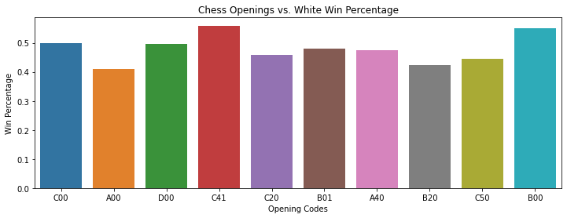

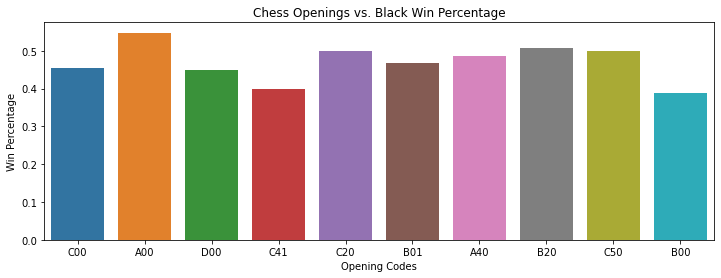

```python
# create new dataframe
barplt = openings
barplt = barplt.drop(columns=['times_played', 'w_wins', 'b_wins'])
barplt = barplt.rename(columns = {'opening_code':'Opening_Code', 'w_win_perc':'White_Win_Percentage', 'b_win_perc':'Black_Win_Percentage'})

# create plot and set dimensions
fig, ax = plt.subplots()
fig.set_figwidth(12)

# plot white win percentage
ax = sns.barplot(x="Opening_Code", y='White_Win_Percentage', data=barplt)
plt.xlabel("Opening Codes")
plt.ylabel("Win Percentage")
plt.title("Chess Openings vs. White Win Percentage")
plt.show()

# create plot and set dimensions
fig, ax = plt.subplots()
fig.set_figwidth(12)
ax = sns.barplot(x="Opening_Code", y='Black_Win_Percentage', data=barplt)
plt.xlabel("Opening Codes")
plt.ylabel("Win Percentage")
plt.title("Chess Openings vs. Black Win Percentage")
plt.show()
```

Now that the win percentages can be seen by both colors on the bar graphs, let's choose opening codes to determine if there is some correlation between openings and winning. The major differences in win percentage between the two can be seen with openings `A00`, `C41`, `B20` and `B00`. Let's see if we can find anything more valuable by calculating the win percent difference between white and black.

```python
# store the win percentage differences of each opening
win_percent_dif =[]

# for each row, or opening code
for rows in barplt.itertuples():

    #add the difference to the list
    win_percent_dif.append(rows.White_Win_Percentage - rows.Black_Win_Percentage)

# add to column
barplt['win_perc_dif'] = win_percent_dif

#sort by the column
barplt = barplt.sort_values(by=['win_perc_dif'], ascending=False)
barplt
```

|  | Opening_Code | White_Win_Percentage | Black_Win_Percentage | win_perc_dif |
| --- | --- | --- | --- | --- |
| 9 | B00 | 0.551402 | 0.387850 | 0.163551 |
| 3 | C41 | 0.559028 | 0.399306 | 0.159722 |
| 0 | C00 | 0.500000 | 0.453488 | 0.046512 |
| 2 | D00 | 0.495114 | 0.449511 | 0.045603 |
| 5 | B01 | 0.479705 | 0.468635 | 0.011070 |
| 6 | A40 | 0.474359 | 0.487179 | -0.012821 |
| 4 | C20 | 0.457875 | 0.498168 | -0.040293 |
| 8 | C50 | 0.444444 | 0.500000 | -0.055556 |
| 7 | B20 | 0.423581 | 0.506550 | -0.082969 |
| 1 | A00 | 0.410828 | 0.547771 | -0.136943 |

### Conclusions:

Just from seeing the win percentage difference, we can notice there is some correlation depending on what opening is played. The higher it is, the more likely white is going to win based off of the opening. The lower the number, the more likely black will win the game simply based off of the opening. Black has a tough time all around, when playing against someone within 100 elo of them, going against both `B00` (King's Pawn Opening) and `C41` (Philidor's Defense), winning less than 40 percent of the time. However, black seems to perform the best when the `A00` (Polish (Sokolsky) Opening) and the `B20` (Sicilian Defense) winning 13.7% and 8.2% more times than white.

When previously looking at elo difference vs. win percentage, there seemed to be a logistic regression for win percentage. The greater skewed the player's elos are, the higher probability that the higher rating will win. When the elo's are close to one another, it becomes more inconclusive on who will win. The elo difference has a logistic correlation with winning percentage. This is good! That means the elo system works as it is supposed to!

As far as the Data Science Pipeline goes, you can always go back to previous steps if needed. You may need to go back to analyze something you missed as I had to do. I began by plotting the elos of both colors against each other soon to find out that it was meaningless. I calculated the elo difference first and tried to see if there was correlation. Once I created my null and alternate hypothesis, I tested them. Then I had to go fetch more data to analyze chess openings. Hopefully you learned a little more about the data collection, data management, data exploration/visualization, and hypothesis testing through this tutorial. As far as analysis of chess goes, this tutorial has barely touched the surface.